# Practical Machine learning - Project

Arshad Ullah

July 12, 2019

### Objective:

The goal of this project is to detect the manner in which the weight lifting exercises were performed. The data is obtained from the Human Activity recongition (HAR) project. http://groupware.les.inf.puc-rio.br/har (see section on weight lifting). The exercise types are categorized into 5 categories from A to E. The exercise category is stored in the classe variable in the training data. The category “A” is the correct execution of the exercise and all the other values are common mistakes performed while doing the exercise.

### Preparing the data

Two comma separated datasets were obtained from the above source.

Training data –> https://d396qusza40orc.cloudfront.net/predmachlearn/pml-training.csv

Testing data –> https://d396qusza40orc.cloudfront.net/predmachlearn/pml-testing.csv

Each dataset had 160 variables. The training dataset had 19622 observations and the testing dataset had 20 observations.

On inspecting the data it was noticed that several of the variables contained missing values or blank data. These variables were removed from the datasets and only the sensor data variables were kept. Sensors were placed in four positions: Arm, Forearm, Belt and Dumbbell. Each position had magnetic, accelerometer and gyroscope sensors with readings for dimensions x, y and z for each sensor. The total number of variables (including the classe variable) was reduced to 53 for the training data and 52 for the testing data. These will be the predictors for the model.

```r
library(dplyr)

setwd("~\\DataScience\\Machine Learning")

training <- read.csv(".\\pml-training.csv")

testing <- read.csv(".\\pml-testing.csv")



trainSel <- select(training, starts_with("magnet"), starts_with("accel"),
                   starts_with("gyros"),
                   starts_with("yaw_"), starts_with("pitch_"), starts_with("roll_"),
                   starts_with("total_accel"),
                   classe)


testSel <- select(testing, starts_with("magnet"), starts_with("accel"), starts_with("gyros"),
                  starts_with("yaw_"), starts_with("pitch_"), starts_with("roll_"),
                  starts_with("total_accel"))
```

```r
library(caret)

inTrain <- createDataPartition(y=trainSel$classe,p=0.75, list=FALSE)

trainOnly <- trainSel[inTrain,]

ValidateOnly <- trainSel[-inTrain,]
```

### Estimating model accuracy (Cross-validation)

In order to estimate the model accuracy the k-fold cross-validation approach was used. The number of folds was set to 10. This is important because the model chosen was a Random Forest model.

```r
train_control <- trainControl(method="cv", number=10)
```

### Model Selection

Iniitially the tree approach was used with all the variables other than classe as the predictors. The output model performed very poorly and had an accuracy of approx 50% which was unacceptable. Next the random forest approach was applied with the number of trees set to 100. This provided very good results and the accuracy of the model against the validation data produced a 99.2% accuracy. The train function in the caret package was used to generate the model.

```r
mod.rf <- train(classe ~., method = "rf", trControl=train_control, data = trainOnly, prox=FALSE, ntree=100)

print(mod.rf)
```

```
## Random Forest
##
## 14718 samples
##    52 predictor
##     5 classes: 'A', 'B', 'C', 'D', 'E'
##
## No pre-processing
## Resampling: Cross-Validated (10 fold)
## Summary of sample sizes: 13245, 13248, 13245, 13247, 13247, 13246, ...
## Resampling results across tuning parameters:
##
##   mtry  Accuracy   Kappa
##    2    0.9920512  0.9899440
##   27    0.9929339  0.9910611
##   52    0.9908958  0.9884822
##
## Accuracy was used to select the optimal model using the largest value.
## The final value used for the model was mtry = 27.
```

### Validation of the model

Next we will use the model created to predict the output variable in the validation dataset and compare it against the actual output variable in the dataset.

```r
pred.val.rf <- predict(mod.rf, newdata = ValidateOnly)

confusionMatrix(pred.val.rf, ValidateOnly$classe)
```

```
## Confusion Matrix and Statistics
##
##           Reference
## Prediction    A    B    C    D    E
##          A 1393    9    0    0    1
##          B    0  935    3    0    0
##          C    1    5  848    9    0
##          D    0    0    4  794    1
##          E    1    0    0    1  899
##
## Overall Statistics
##
##                Accuracy : 0.9929
##                  95% CI : (0.9901, 0.995)
##     No Information Rate : 0.2845
##     P-Value [Acc > NIR] : < 2.2e-16
##
##                   Kappa : 0.991
##  Mcnemar's Test P-Value : NA
##
## Statistics by Class:
##
##                      Class: A Class: B Class: C Class: D Class: E
## Sensitivity            0.9986   0.9852   0.9918   0.9876   0.9978
## Specificity            0.9972   0.9992   0.9963   0.9988   0.9995
## Pos Pred Value         0.9929   0.9968   0.9826   0.9937   0.9978
## Neg Pred Value         0.9994   0.9965   0.9983   0.9976   0.9995
## Prevalence             0.2845   0.1935   0.1743   0.1639   0.1837
## Detection Rate         0.2841   0.1907   0.1729   0.1619   0.1833
## Detection Prevalence   0.2861   0.1913   0.1760   0.1629   0.1837
## Balanced Accuracy      0.9979   0.9922   0.9941   0.9932   0.9986
```

### Plots

Shown below are plots of the model accuracy against the number of predictors. As seen the accuracy of the model remains high upto about 27 predictors but beyond that the accuracy goes down linearly.

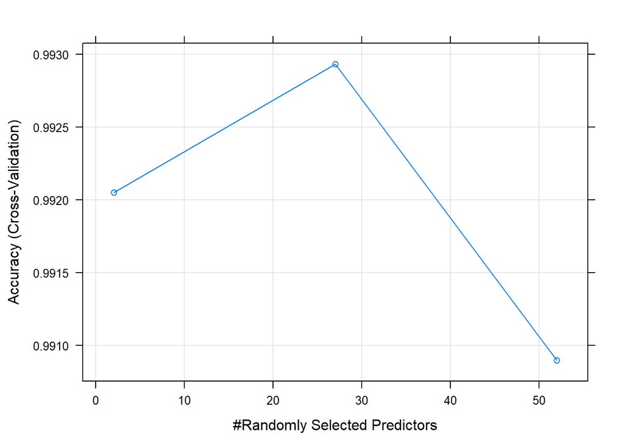

Next we will plot the error rate (the black line is the out of sample (or out of bag) error rate) against the number of trees. The out of sample error reduces exponentially as the number of trees increase.

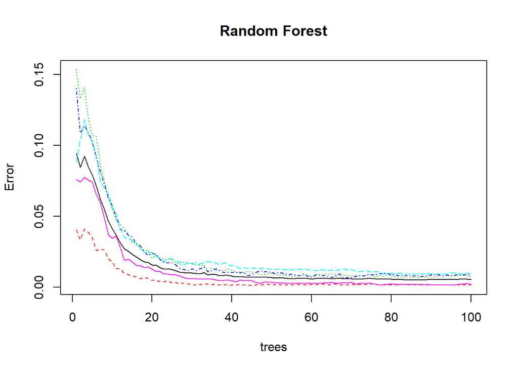

### Variable importance

Below are listed the predictors in the order of descending importance. First 20 are shown.

```r
varImp(mod.rf)
```

```
## rf variable importance
##
##   only 20 most important variables shown (out of 52)
##
##                      Overall
## roll_belt            100.000
## pitch_forearm         64.752
## yaw_belt              59.178
## magnet_dumbbell_z     46.595
## pitch_belt            46.053
## magnet_dumbbell_y     43.859
## roll_forearm          39.999
## accel_dumbbell_y      22.108
## roll_dumbbell         19.111
## magnet_belt_z         17.752
## magnet_dumbbell_x     17.745
## accel_forearm_x       17.143
## accel_belt_z          15.671
## accel_dumbbell_z      14.832
## total_accel_dumbbell  13.420
## magnet_forearm_z      13.178
## gyros_belt_z          11.363
## magnet_belt_y         11.351
## yaw_arm               10.874
## roll_arm               9.807
```